# HW_03

MINSI SUNG

26/09/2019

# Pick three of the six tasks below, and produce:

- a tibble, using dplyr as your data manipulation tool;
- an accompanying plot of data from the tibble, using ggplot2 as your visualization tool; and
- some dialogue about what your tables/figures show (doesn’t have to be much).

### For this assignment, I chose option 2,3 and 5 for the requirements

# Task Option 2

### Get the maximum and minimum of GDP per capita for all continents.

So, here I grouped the gapminder by cotinent and used summarize to create four new coloumns with max and min function. Finally used datatable() to make a prettier table.

```r
Option2 = gapminder %>%
  group_by(continent) %>%
  summarize(Max_gdpPercap = max(gdpPercap),`Max Country` = country[gdpPercap==`Max_gdpPercap`], Min_gdpPercap = min(gdpPercap),`Min Country` = country[gdpPercap==`Min_gdpPercap`])

DT::datatable(Option2)
```

|  | continent | Max_gdpPercap | Max Country | Min_gdpPercap | Min Country |
| --- | --- | --- | --- | --- | --- |
| 1 | Africa | 21951.21176 | Libya | 241.1658765 | Congo, Dem. Rep. |
| 2 | Americas | 42951.65309 | United States | 1201.637154 | Haiti |
| 3 | Asia | 113523.1329 | Kuwait | 331 | Myanmar |
| 4 | Europe | 49357.19017 | Norway | 973.5331948 | Bosnia and Herzegovina |
| 5 | Oceania | 34435.36744 | Australia | 10039.59564 | Australia |

Used the table above and filter out the max and min country to create a column plot.

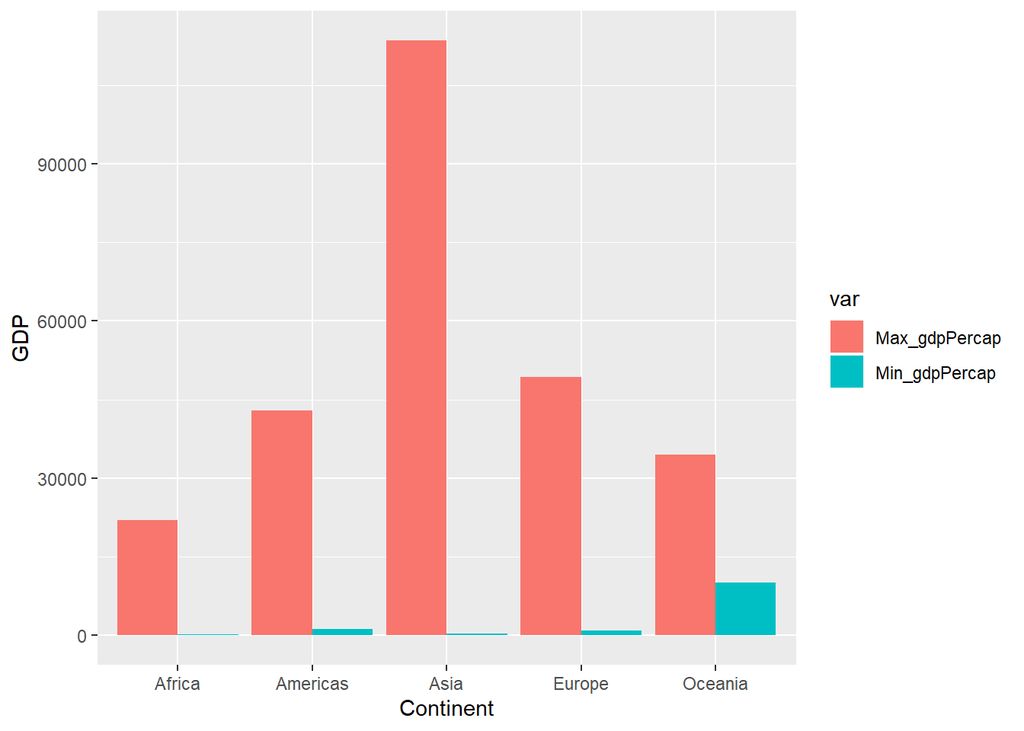

```r
Option2 %>%
    select(continent,Max_gdpPercap,Min_gdpPercap) %>%
    gather(var, gdp, -continent)%>%
    ggplot(aes(x = continent, y = gdp, fill = var)) +
    geom_col(position = position_dodge()) +
    xlab('Continent')+
    ylab('GDP')
```

# Task Option 3

### Look at the spread of GDP per capita within the continents.

For the table I just select continent and gdpercap and group by the cotninent.

```r
Option3 <- gapminder %>%
  group_by(continent) %>%
  select(continent,gdpPercap)
Option3
```

```
## # A tibble: 1,704 x 2
## # Groups:   continent [5]
##    continent gdpPercap
##    <fct>         <dbl>
##  1 Asia           779.
##  2 Asia           821.
##  3 Asia           853.
##  4 Asia           836.
##  5 Asia           740.
##  6 Asia           786.
##  7 Asia           978.
##  8 Asia           852.
##  9 Asia           649.
## 10 Asia           635.
## # ... with 1,694 more rows
```

Then I used the two ways to show the spread of GDP per capita within the continent.

First one used geom_boxplot to plot the GDP per capita of all the countries which are in the same cotinent. Also use the table with differnet colors for each cotinent to fulfill the optional exercise

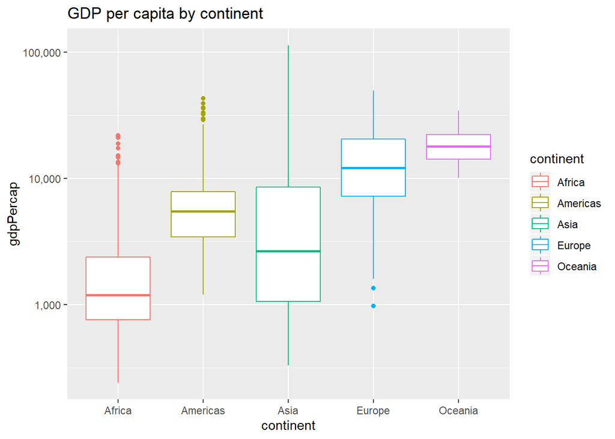

```r
Option3 %>%
  ggplot(aes(continent, gdpPercap, color = continent)) +
  geom_boxplot() +
  scale_y_log10(labels = scales::comma_format())+
  ggtitle("GDP per capita by continent")
```

Second way is using histogram to show the spread of GDP per capita within the continents and put into the same plot for comparison.

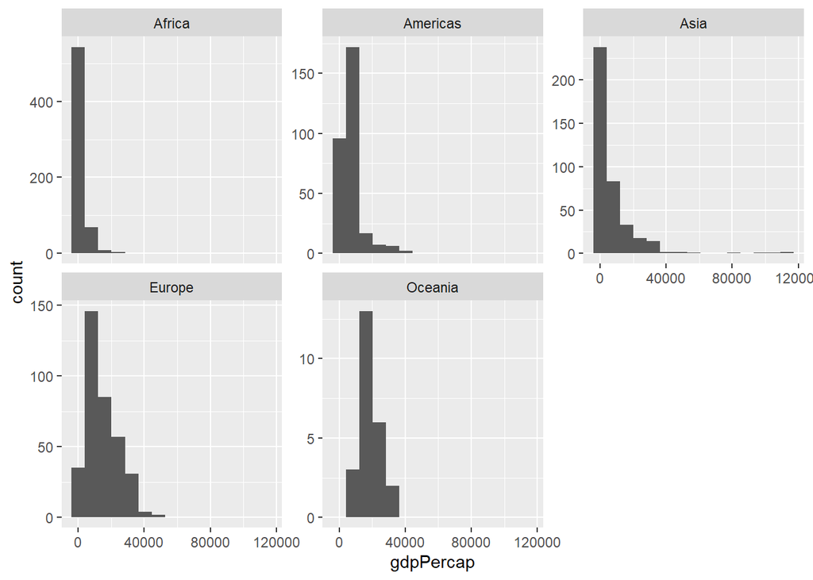

```r
Option3 %>%
ggplot(aes(gdpPercap)) +
  geom_histogram(bins = 15)+
  facet_wrap(~continent, scales = "free_y")
```

# Task Option 5

### How is life expectancy changing over time on different continents?

Since there are lots of lifeExp data in each continent, I need to get the mean of the lifeExp for each continent and plot its changing over time.

```r
Option5 <- gapminder %>%
  group_by(continent,year) %>%
  summarize(mean_lifeExp = mean(lifeExp))
  DT::datatable(Option5)
```

|  | continent | year | mean_lifeExp |
| --- | --- | --- | --- |
| 1 | Africa | 1952 | 39.1355 |
| 2 | Africa | 1957 | 41.2663461538462 |
| 3 | Africa | 1962 | 43.3194423076923 |
| 4 | Africa | 1967 | 45.3345384615385 |
| 5 | Africa | 1972 | 47.4509423076923 |
| 6 | Africa | 1977 | 49.5804230769231 |
| 7 | Africa | 1982 | 51.5928653846154 |
| 8 | Africa | 1987 | 53.3447884615385 |
| 9 | Africa | 1992 | 53.6295769230769 |
| 10 | Africa | 1997 | 53.5982692307692 |

[output cut: 50 more lines]

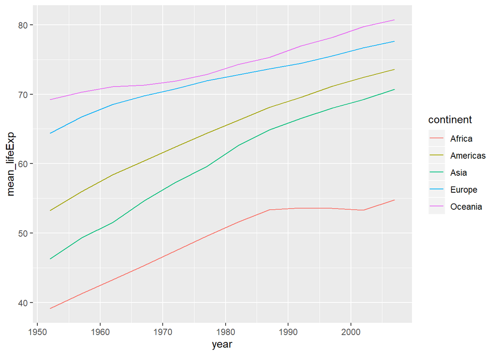

```r
Option5 %>%
  ggplot(aes(year, mean_lifeExp, group = continent, colour = continent)) +
  geom_line()
```

# Optional Exercise